```python
import warnings
warnings.filterwarnings("ignore")

import pandas as pd
import numpy as np

# Plots
import matplotlib.pyplot as plt
import seaborn as sns

# Prep
from sklearn.preprocessing import MinMaxScaler
from sklearn.impute import KNNImputer

# Clustering
from sklearn.cluster import KMeans
from yellowbrick.cluster import SilhouetteVisualizer

# Classification
from sklearn.model_selection import train_test_split, cross_val_score
from sklearn.metrics import confusion_matrix, accuracy_score, precision_score, recall_score, f1_score, make_scorer
from sklearn.model_selection import GridSearchCV, StratifiedKFold

# Models
from sklearn.naive_bayes import GaussianNB
from sklearn.linear_model import LogisticRegression
from sklearn.neighbors import KNeighborsClassifier
from sklearn import svm
from sklearn.tree import DecisionTreeClassifier
from sklearn.ensemble import RandomForestClassifier, AdaBoostClassifier
from xgboost import XGBClassifier
from catboost import CatBoostClassifier
```

# Heart Failure Prediction Dataset

"Cardiovascular diseases (CVDs) are the number 1 cause of death globally, taking an estimated 17.9 million lives each year, which accounts for 31% of all deaths worldwide. Four out of 5CVD deaths are due to heart attacks and strokes, and one-third of these deaths occur prematurely in people under 70 years of age. Heart failure is a common event caused by CVDs and this dataset contains 11 features that can be used to predict a possible heart disease."

Link: https://www.kaggle.com/fedesoriano/heart-failure-prediction

### Attribute Information

**Age**: age of the patient [years]

**Sex**: sex of the patient [M: Male, F: Female]

**ChestPainType**: chest pain type [TA: Typical Angina, ATA: Atypical Angina, NAP: Non-Anginal Pain, ASY: Asymptomatic]

**RestingBP**: resting blood pressure [mm Hg]

**Cholesterol**: serum cholesterol [mm/dl]

**FastingBS**: fasting blood sugar [1: if FastingBS > 120 mg/dl, 0: otherwise]

**RestingECG**: resting electrocardiogram results [Normal: Normal, ST: having ST-T wave abnormality (T wave inversions and/or ST elevation or depression of > 0.05 mV), LVH: showing probable or definite left ventricular hypertrophy by Estes' criteria]

**MaxHR**: maximum heart rate achieved [Numeric value between 60 and 202]

**ExerciseAngina**: exercise-induced angina [Y: Yes, N: No]

**Oldpeak**: oldpeak = ST [Numeric value measured in depression]

**ST_Slope**: the slope of the peak exercise ST segment [Up: upsloping, Flat: flat, Down: downsloping]

**HeartDisease**: output class [1: heart disease, 0: Normal]

```python
df = pd.read_csv('heart.csv')
df.head().style.hide_index()
```

| Age | Sex | ChestPainType | RestingBP | Cholesterol | FastingBS | RestingECG | MaxHR | ExerciseAngina | Oldpeak | ST_Slope | HeartDisease |
| --- | --- | --- | --- | --- | --- | --- | --- | --- | --- | --- | --- |
| 40 | M | ATA | 140 | 289 | 0 | Normal | 172 | N | 0.000000 | Up | 0 |
| 49 | F | NAP | 160 | 180 | 0 | Normal | 156 | N | 1.000000 | Flat | 1 |
| 37 | M | ATA | 130 | 283 | 0 | ST | 98 | N | 0.000000 | Up | 0 |
| 48 | F | ASY | 138 | 214 | 0 | Normal | 108 | Y | 1.500000 | Flat | 1 |
| 54 | M | NAP | 150 | 195 | 0 | Normal | 122 | N | 0.000000 | Up | 0 |

```python
len(df)
```

```
918
```

## Goals

Hlavním cílem u tohoto datasetu bude předpovědět, zda člověk trpí srdeční nemocí nebo ne.

## Data cleaning

Sloupec cholesterol obsahuje záznamy s nulovou hodnotou (s největší pravděpodobností chybějící hodnoty).

```python
df['Cholesterol'] = df['Cholesterol'].mask(df['Cholesterol'] == 0, np.NaN)
```

Dataset obsahuje jeden řádek s nulovou hodnotou u více měření. Vzhledem k velikosti datasetu řádek můžeme odstranit.

```python
df.loc[df['RestingBP'] == 0]
```

|  | Age | Sex | ChestPainType | RestingBP | Cholesterol | FastingBS | RestingECG | MaxHR | ExerciseAngina | Oldpeak | ST_Slope | HeartDisease |
| --- | --- | --- | --- | --- | --- | --- | --- | --- | --- | --- | --- | --- |
| 449 | 55 | M | NAP | 0 | NaN | 0 | Normal | 155 | N | 1.5 | Flat | 1 |

```python
df = df.loc[df['RestingBP']  > 0]
```

## Dataset overview

```python
df.describe()
```

|  | Age | RestingBP | Cholesterol | FastingBS | MaxHR | Oldpeak | HeartDisease |
| --- | --- | --- | --- | --- | --- | --- | --- |
| count | 917.000000 | 917.000000 | 746.000000 | 917.000000 | 917.000000 | 917.000000 | 917.000000 |
| mean | 53.509269 | 132.540894 | 244.635389 | 0.233370 | 136.789531 | 0.886696 | 0.552890 |
| std | 9.437636 | 17.999749 | 59.153524 | 0.423206 | 25.467129 | 1.066960 | 0.497466 |
| min | 28.000000 | 80.000000 | 85.000000 | 0.000000 | 60.000000 | -2.600000 | 0.000000 |
| 25% | 47.000000 | 120.000000 | 207.250000 | 0.000000 | 120.000000 | 0.000000 | 0.000000 |
| 50% | 54.000000 | 130.000000 | 237.000000 | 0.000000 | 138.000000 | 0.600000 | 1.000000 |
| 75% | 60.000000 | 140.000000 | 275.000000 | 0.000000 | 156.000000 | 1.500000 | 1.000000 |
| max | 77.000000 | 200.000000 | 603.000000 | 1.000000 | 202.000000 | 6.200000 | 1.000000 |

```python
df.describe(include=['O'])
```

|  | Sex | ChestPainType | RestingECG | ExerciseAngina | ST_Slope |
| --- | --- | --- | --- | --- | --- |
| count | 917 | 917 | 917 | 917 | 917 |
| unique | 2 | 4 | 3 | 2 | 3 |
| top | M | ASY | Normal | N | Flat |
| freq | 724 | 496 | 551 | 546 | 459 |

#### Null and duplicit analysis

|  | Age | Sex | ChestPainType | RestingBP | Cholesterol | FastingBS | RestingECG | MaxHR | ExerciseAngina | Oldpeak | ST_Slope | HeartDisease |
| --- | --- | --- | --- | --- | --- | --- | --- | --- | --- | --- | --- | --- |
| Sum | 0 | 0 | 0 | 0 | 171 | 0 | 0 | 0 | 0 | 0 | 0 | 0 |
| % | 0.0 | 0.0 | 0.0 | 0.0 | 18.6 | 0.0 | 0.0 | 0.0 | 0.0 | 0.0 | 0.0 | 0.0 |

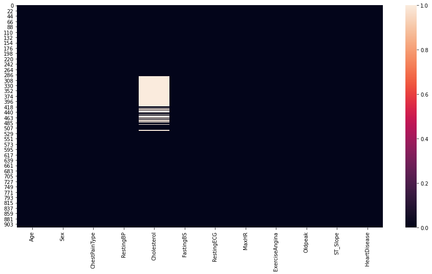

```python
def null_value_analysis(df):
    nulls = df.isnull().sum()
    null_sum = nulls.sum()

    if(null_sum == 0):
        return 'No missing values.'
    else:
        null_df = pd.DataFrame(columns = df.columns)
        null_df.loc['Sum'] = nulls
        null_df.loc['%'] = round((nulls / len(df)) * 100, 1)
        display(null_df)

        # Heatmap
        plt.figure(figsize = (16, 8))
        sns.heatmap(data = df.isnull())
        plt.show()
        null_df

null_value_analysis(df)
```

Sloupec 'Cholesterol' obsahuje téměř 19% chybějících hodnot.

```python
def duplicate_analysis(df):
    print(str(df.duplicated().sum()) + ' identical rows.')

    col_dup = []
    unq = []
    for cn in df.columns:
        col_dup.append(df[cn].duplicated().sum())
        unq.append(len(df[cn].unique()))

    dup_df = pd.DataFrame(columns = df.columns)
    dup_df.loc['Duplicate values'] = col_dup
    dup_df.loc['Unique values'] = unq

    display(dup_df)

duplicate_analysis(df)
```

```
0 identical rows.
```

|  | Age | Sex | ChestPainType | RestingBP | Cholesterol | FastingBS | RestingECG | MaxHR | ExerciseAngina | Oldpeak | ST_Slope | HeartDisease |
| --- | --- | --- | --- | --- | --- | --- | --- | --- | --- | --- | --- | --- |
| Duplicate values | 867 | 915 | 913 | 851 | 695 | 915 | 914 | 798 | 915 | 864 | 914 | 915 |
| Unique values | 50 | 2 | 4 | 66 | 222 | 2 | 3 | 119 | 2 | 53 | 3 | 2 |

Žádné duplicitní řádky.

# Exploratory Data Analysis

```python
sns.reset_orig()
pal = 'YlOrBr'
col = 'orange'
```

### HeartDisease (Target column)

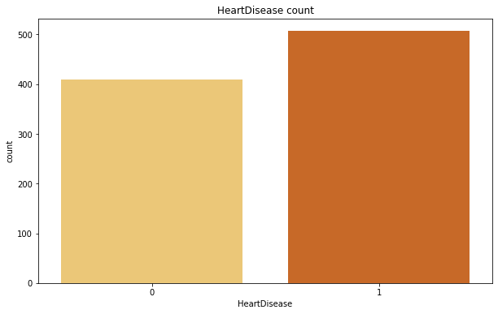

```python
plt.figure(figsize = (10, 6))
sns.countplot(data = df, x = 'HeartDisease', palette = pal).set_title('HeartDisease count')
plt.show()
```

### Age

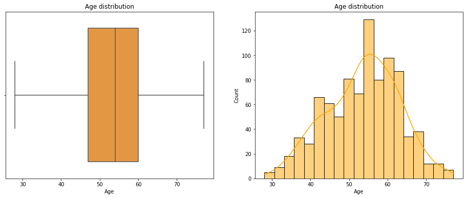

```python
fig, ax = plt.subplots(1, 2, figsize = (16, 6))
sns.boxplot(data = df, x = 'Age', palette = pal, ax = ax[0]).set_title('Age distribution')
sns.histplot(data = df, x = 'Age', kde = True, ax=ax[1], color = col).set_title('Age distribution')
fig.show()
```

```python
print("Skewness: %f" % df['Age'].skew())
print("Kurtosis: %f" % df['Age'].kurt())
```

```
Skewness: -0.195322
Kurtosis: -0.388986
```

**Pozorování**

- Bez odlehlých pozorování.
- Distrubuce má normální rozdelení.
- Většina sledovaných lidí se řadí do intervalu 40 - 65 let.

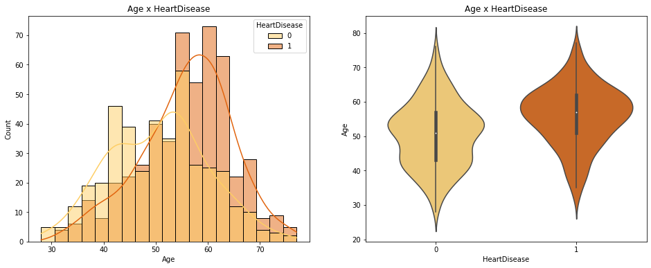

```python
fig, ax = plt.subplots(1, 2, figsize=(16, 6))
sns.histplot(data = df, hue = 'HeartDisease', x = 'Age', kde = True, palette = pal, ax=ax[0]).set_title('Age x HeartDisease')
sns.violinplot(data = df, x = 'HeartDisease', y = 'Age', palette = pal, ax=ax[1]).set_title('Age x HeartDisease')
fig.show()
```

**Pozorování**

- Starší lidé mají větší pravděpodobnost srdeční nemoci.
- Lidé pod 35 let trpí srdečním onemocněním pouze vzácně.

### Sex

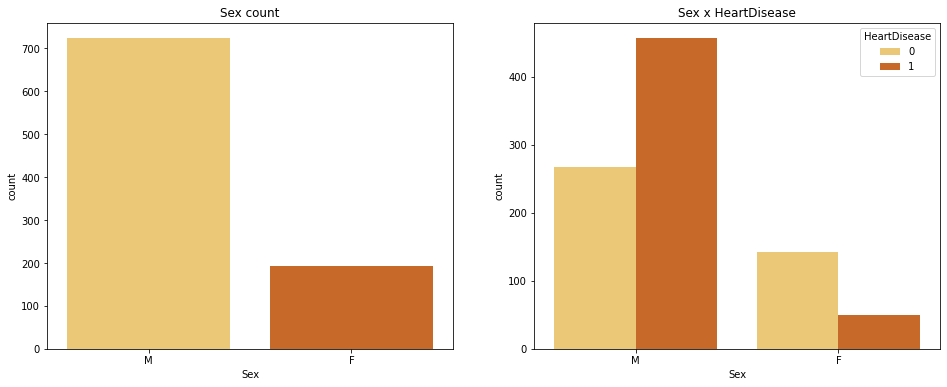

```python
fig, ax = plt.subplots(1, 2, figsize=(16, 6))
sns.countplot(data = df, x = 'Sex', palette = pal, ax=ax[0]).set_title('Sex count')
sns.countplot(data = df, x = 'Sex', hue = 'HeartDisease', palette = pal, ax=ax[1]).set_title('Sex x HeartDisease')
fig.show()
```

```python
ct = pd.crosstab(df['Sex'], df['HeartDisease'], margins = True).style.background_gradient(cmap = pal)
ct
```

| HeartDisease Sex | 0 | 1 | All |
| --- | --- | --- | --- |
| F | 143 | 50 | 193 |
| M | 267 | 457 | 724 |
| All | 410 | 507 | 917 |

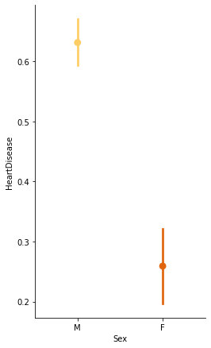

| Sex | HeartDisease |
| --- | --- |
| F | 0.259067 |
| M | 0.631215 |

```python
sns.factorplot(data = df, x = 'Sex', y = 'HeartDisease', palette = pal, size = 6, aspect = 0.6)
plt.show()

df[['Sex', 'HeartDisease']].groupby(['Sex'], as_index = False).mean().style.hide_index()
```

**Pozorování**

- V datasetu značně převažují muži.
- Muži jsou více než dvojnásobně náchylnější na srdeční nemoci.

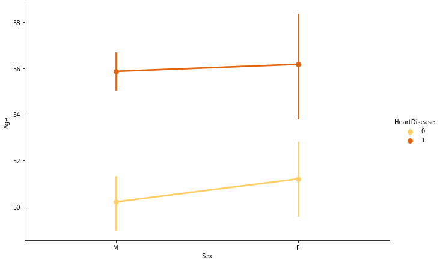

```python
plt.figure(figsize = (14, 8))
sns.factorplot(data = df, x = 'Sex', y = 'Age', hue = 'HeartDisease', palette = pal, size = 6, aspect = 1.5)
plt.show()
```

**Pozorování**

- Průměrný věk nemocných žen i mužů je téměř shodný.

### ChestPainType

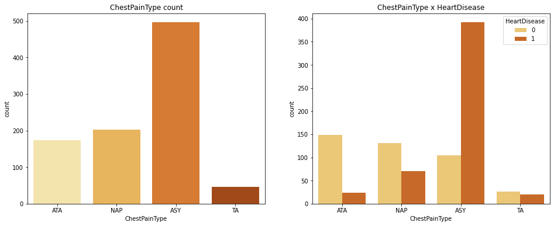

```python
fig, ax = plt.subplots(1, 2, figsize=(16, 6))
sns.countplot(data = df, x = 'ChestPainType', palette = pal, ax=ax[0]).set_title('ChestPainType count')
sns.countplot(data = df, x = 'ChestPainType', hue = 'HeartDisease', palette = pal, ax=ax[1]).set_title('ChestPainType x HeartDisease')
fig.show()
```

```python
ct = pd.crosstab(df['ChestPainType'], df['HeartDisease'], margins = True).style.background_gradient(cmap = pal)
ct
```

| HeartDisease ChestPainType | 0 | 1 | All |
| --- | --- | --- | --- |
| ASY | 104 | 392 | 496 |
| ATA | 149 | 24 | 173 |
| NAP | 131 | 71 | 202 |
| TA | 26 | 20 | 46 |
| All | 410 | 507 | 917 |

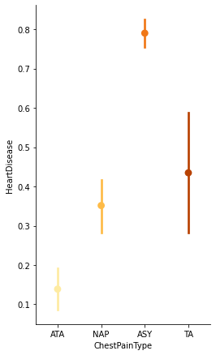

| ChestPainType | HeartDisease |
| --- | --- |
| ASY | 0.790323 |
| ATA | 0.138728 |
| NAP | 0.351485 |
| TA | 0.434783 |

```python
sns.factorplot(data = df, x = 'ChestPainType', y = 'HeartDisease', palette = pal, size = 6, aspect = 0.6)
plt.show()

df[['ChestPainType', 'HeartDisease']].groupby(['ChestPainType'], as_index = False).mean().style.hide_index()
```

**Pozorování**

- Pacientů s typem bolesti ASY je v datasetu značně nejvíce a také je u nich nejvýraznější riziko srdeční nemoci (79%).
- Nejmenší procento případů se srdeční nemocí je u pacientů s typem bolesti ATA (14%).

```python
df[df.Sex == 'F'][['ChestPainType', 'HeartDisease']].groupby(['ChestPainType'], as_index = False).mean().style.hide_index()
```

| ChestPainType | HeartDisease |
| --- | --- |
| ASY | 0.557143 |
| ATA | 0.066667 |
| NAP | 0.113208 |
| TA | 0.100000 |

[figure not shown]

```python
grid = sns.FacetGrid(df, col = 'Sex', size = 4.5, aspect = 0.8).map(sns.pointplot, 'ChestPainType', 'HeartDisease', palette = pal)
plt.show()
```

**Pozorování**

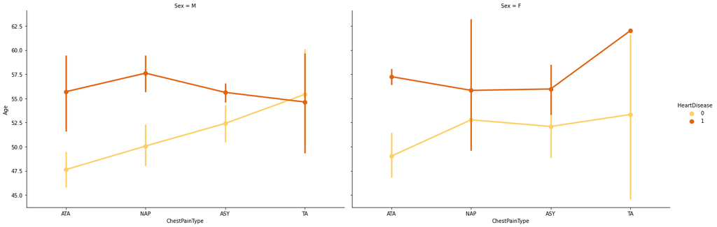

```python
sns.factorplot(data = df, x = 'ChestPainType', y = 'Age', hue = 'HeartDisease', col = 'Sex', palette = pal, size = 6, aspect = 1.5)
plt.show()
```

**Pozorování**

- Typ bolesti TA se u žen se srdeční nemocí vyskytuje v pozdějším věku než ostatní typy bolestí (může být způsobeno nízkým počtem TA záznamů a žen v datasetu).

### RestingBP

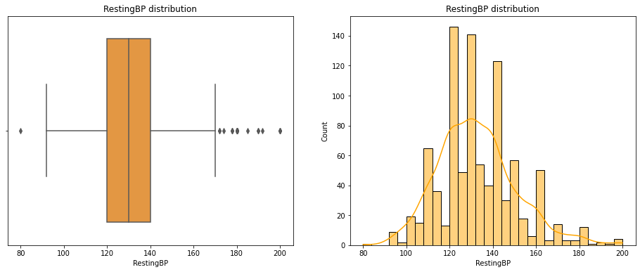

```python
fig, ax = plt.subplots(1, 2, figsize=(16, 6))
sns.boxplot(data = df, x = 'RestingBP', palette = pal, ax = ax[0]).set_title('RestingBP distribution')
sns.histplot(data = df, x = 'RestingBP', kde = True, color = col, ax = ax[1]).set_title('RestingBP distribution')
fig.show()
```

```python
print("Skewness: %f" % df['RestingBP'].skew())
print("Kurtosis: %f" % df['RestingBP'].kurt())
```

```
Skewness: 0.607195
Kurtosis: 0.791851
```

**Pozorování**

- Data obsahují odlehlá pozorování.
- Distrubuce má normální rozdělení.

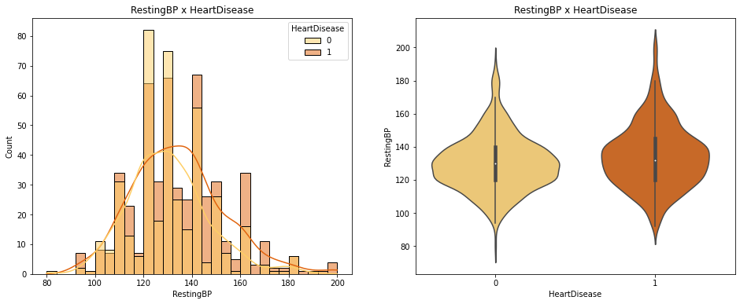

```python
fig, ax = plt.subplots(1, 2, figsize=(16, 6))
sns.histplot(data = df, hue = 'HeartDisease', x = 'RestingBP', kde = True, palette = pal, ax=ax[0]).set_title('RestingBP x HeartDisease')
sns.violinplot(data = df, x = 'HeartDisease', y = 'RestingBP', palette = pal, ax=ax[1]).set_title('RestingBP x HeartDisease')
fig.show()
```

**Pozorování**

- Výskyt srdeční nemoci se nezdá být významně propojen s klidovým krevním tlakem

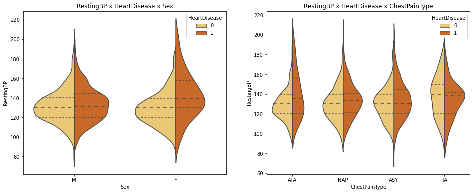

```python
fig, ax = plt.subplots(1, 2, figsize=(16, 6))
sns.violinplot(data = df, x = 'Sex', y = 'RestingBP', hue = 'HeartDisease', palette = pal, size = 6, aspect = 1.5, split = True, inner = 'quart', ax=ax[0]).set_title('RestingBP x HeartDisease x Sex')
sns.violinplot(data = df, x = 'ChestPainType', y = 'RestingBP', hue = 'HeartDisease', palette = pal, size = 6, aspect = 1.5, split = True, inner = 'quart', ax=ax[1]).set_title('RestingBP x HeartDisease x ChestPainType')
fig.show()
```

**Pozorování**

- Ženy se srdečním onemocněním mají v průměru větší klidový krevní tlak než ženy bez srdečního onemocnění.
- Výskyt srdeční nemoci se nezdá být významně propojen s klidovým krevním tlakem u mužů nebo s typem bolesti.

### Cholesterol

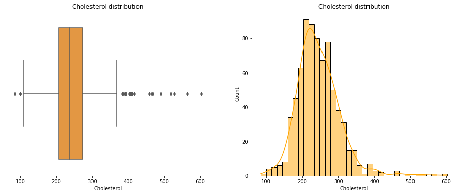

```python
fig, ax = plt.subplots(1, 2, figsize=(16, 6))
sns.boxplot(data = df, x = 'Cholesterol', palette = pal, ax = ax[0]).set_title('Cholesterol distribution')
sns.histplot(data = df, x = 'Cholesterol', kde = True, color = col, ax = ax[1]).set_title('Cholesterol distribution')
fig.show()
```

```python
print("Skewness: %f" % df['RestingBP'].skew())
print("Kurtosis: %f" % df['RestingBP'].kurt())
```

```
Skewness: 0.607195
Kurtosis: 0.791851
```

**Pozorování**

- Data obsahují odlehlá pozorování.
- Distrubuce má normální rozdělení.

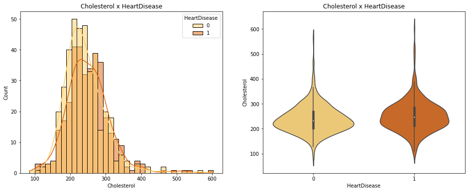

```python
fig, ax = plt.subplots(1, 2, figsize=(16, 6))
sns.histplot(data = df, hue = 'HeartDisease', x = 'Cholesterol', kde = True, palette = pal, ax=ax[0]).set_title('Cholesterol x HeartDisease')
sns.violinplot(data = df, x = 'HeartDisease', y = 'Cholesterol', palette = pal, ax=ax[1]).set_title('Cholesterol x HeartDisease')
fig.show()
```

**Pozorování**

- Výskyt srdeční nemoci se nezdá být významně propojen s větším množstvím cholesterolu v těle.

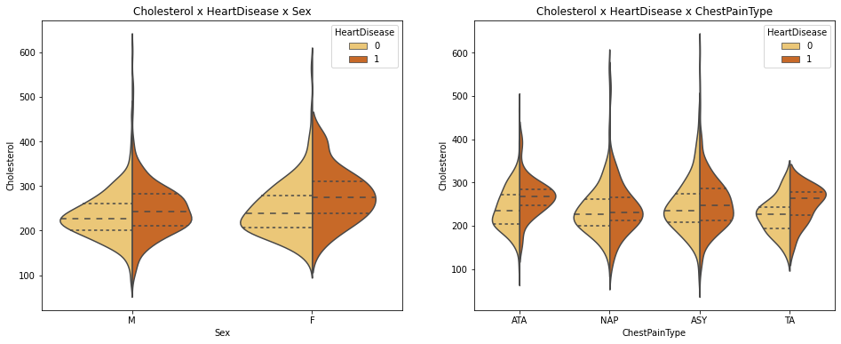

```python
fig, ax = plt.subplots(1, 2, figsize=(16, 6))
sns.violinplot(data = df, x = 'Sex', y = 'Cholesterol', hue = 'HeartDisease', palette = pal, size = 6, aspect = 1.5, split = True, inner = 'quart', ax=ax[0]).set_title('Cholesterol x HeartDisease x Sex')
sns.violinplot(data = df, x = 'ChestPainType', y = 'Cholesterol', hue = 'HeartDisease', palette = pal, size = 6, aspect = 1.5, split = True, inner = 'quart', ax=ax[1]).set_title('Cholesterol x HeartDisease x ChestPainType')
fig.show()
```

**Pozorování**

- Ženy i muži (muži pouze lehce) se srdečním onemocněním mají v průměru větší hodnotu cholesterolu než ženy bez srdečního onemocnění.
- Pacienti s typem bolesti ATA a TA a srdeční nemocí mají taktéž v průměru větší hodnotu cholesterolu než odpovídající pacienti bez srdeční nemoci.

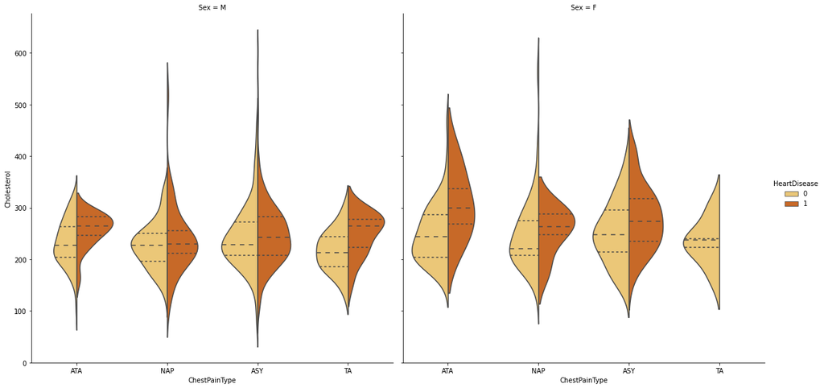

```python
sns.catplot(data = df, x = 'ChestPainType', y = 'Cholesterol', hue = 'HeartDisease', col = 'Sex', kind="violin", split=True, inner = 'quart', palette = pal, size = 8)
fig.show()
```

**Pozorování**

- Ženy s typem bolesti NAP mají v průměru výrazně větší hladinu cholesterolu než odpovídající muži.

### FastingBS

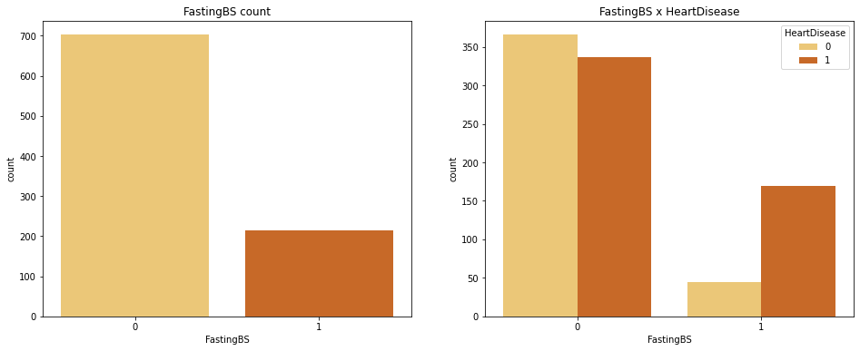

```python
fig, ax = plt.subplots(1, 2, figsize=(16, 6))
sns.countplot(data = df, x = 'FastingBS', palette = pal, ax = ax[0]).set_title('FastingBS count')
sns.countplot(data = df, x = 'FastingBS', hue = 'HeartDisease', palette = pal, ax = ax[1]).set_title('FastingBS x HeartDisease')
fig.show()
```

```python
ct = pd.crosstab(df['FastingBS'], df['HeartDisease'], margins = True).style.background_gradient(cmap = pal)
ct
```

| HeartDisease FastingBS | 0 | 1 | All |
| --- | --- | --- | --- |
| 0 | 366 | 337 | 703 |
| 1 | 44 | 170 | 214 |
| All | 410 | 507 | 917 |

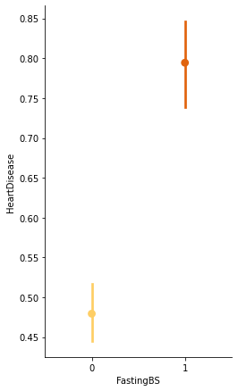

| FastingBS | HeartDisease |
| --- | --- |
| 0 | 0.479374 |
| 1 | 0.794393 |

```python
sns.factorplot(data = df, x = 'FastingBS', y = 'HeartDisease', palette = pal, size = 6, aspect = 0.6)
plt.show()

df[['FastingBS', 'HeartDisease']].groupby(['FastingBS'], as_index = False).mean().style.hide_index()
```

**Pozorování**

- Většina pacientů v datasetu má hladinu krevního cukru na lačno pod hranicí 120 mg/dl.
- Pacienti s hladinou krevního cukru na lačno nad 120 mg/dl mají téměř dvojnásobné riziko srdeční nemoci (79%) než zbytek pacientů (48%).

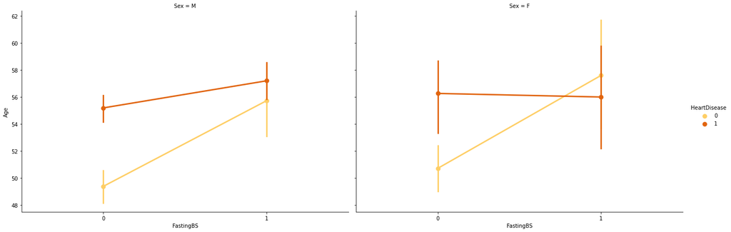

```python
sns.factorplot(data = df, x = 'FastingBS', y = 'Age', hue = 'HeartDisease', col = 'Sex', palette = pal, size = 6, aspect = 1.5)
plt.show()
```

**Pozorování**

- Kromě žen s nemocí srdce v průměru krevní cukr na lačno roste s přibývajícím věkem.

### RestingECG

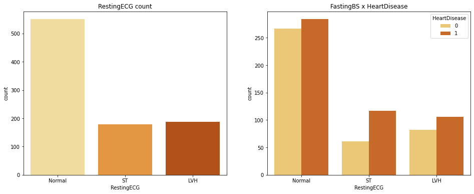

```python
fig, ax = plt.subplots(1, 2, figsize=(16, 6))
sns.countplot(data = df, x = 'RestingECG', palette = pal, ax=ax[0]).set_title('RestingECG count')
sns.countplot(data = df, x = 'RestingECG', hue = 'HeartDisease', palette = pal, ax=ax[1]).set_title('FastingBS x HeartDisease')
fig.show()
```

```python
ct = pd.crosstab(df['RestingECG'], df['HeartDisease'], margins = True).style.background_gradient(cmap = pal)
ct
```

| HeartDisease RestingECG | 0 | 1 | All |
| --- | --- | --- | --- |
| LVH | 82 | 106 | 188 |
| Normal | 267 | 284 | 551 |
| ST | 61 | 117 | 178 |
| All | 410 | 507 | 917 |

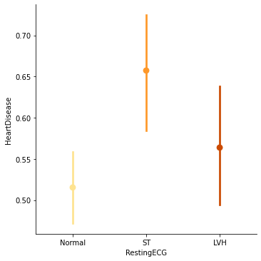

| RestingECG | HeartDisease |
| --- | --- |
| LVH | 0.563830 |
| Normal | 0.515426 |
| ST | 0.657303 |

```python
sns.factorplot(data = df, x = 'RestingECG', y = 'HeartDisease', palette = pal)
plt.show()

df[['RestingECG', 'HeartDisease']].groupby(['RestingECG'], as_index = False).mean().style.hide_index()
```

**Pozorování**

- Nejčastější skupinou jsou pacienti s normální klidovou hodnotou ECG.
- Pacienti s klidovou hodnotou ECG typu ST mají největší riziko srdeční nemoci (cca 66%).

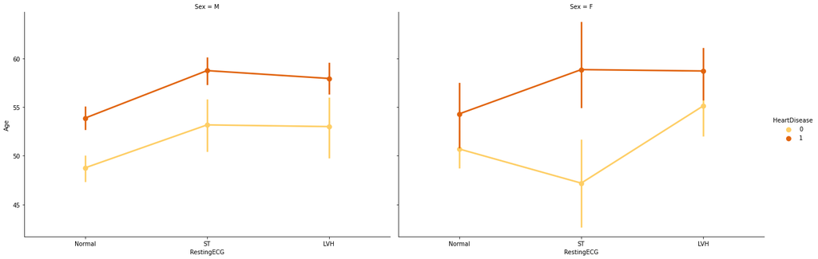

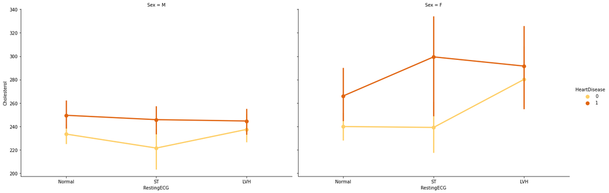

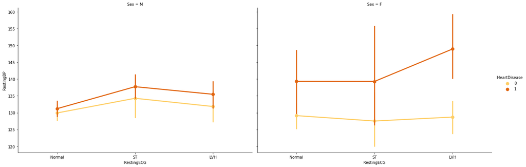

```python
sns.factorplot(data = df, x = 'RestingECG', y = 'Age', hue = 'HeartDisease', col = 'Sex', palette = pal, size = 6, aspect = 1.5)
sns.factorplot(data = df, x = 'RestingECG', y = 'Cholesterol', hue = 'HeartDisease', col = 'Sex', palette = pal, size = 6, aspect = 1.5)
sns.factorplot(data = df, x = 'RestingECG', y = 'RestingBP', hue = 'HeartDisease', col = 'Sex', palette = pal, size = 6, aspect = 1.5)
plt.show()
```

**Pozorování**

- Ženy bez srdeční nemoci s klidovou hodnotou ECG typu ST mají menší průměrný věk než muži.

### MaxHR

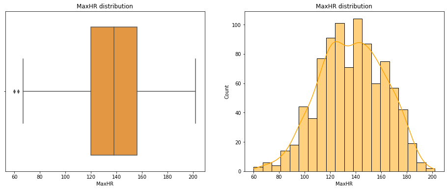

```python
fig, ax = plt.subplots(1, 2, figsize=(16, 6))
sns.boxplot(data = df, x = 'MaxHR', palette = pal, ax = ax[0]).set_title('MaxHR distribution')
sns.histplot(data = df, x = 'MaxHR', kde = True, color = col, ax = ax[1]).set_title('MaxHR distribution')
fig.show()
```

```python
print("Skewness: %f" % df['MaxHR'].skew())
print("Kurtosis: %f" % df['MaxHR'].kurt())
```

```
Skewness: -0.142459
Kurtosis: -0.448915
```

**Pozorování**

- Data obsahují malé množtví odlehlých pozorování.
- Distrubuce má normální rozdělení.

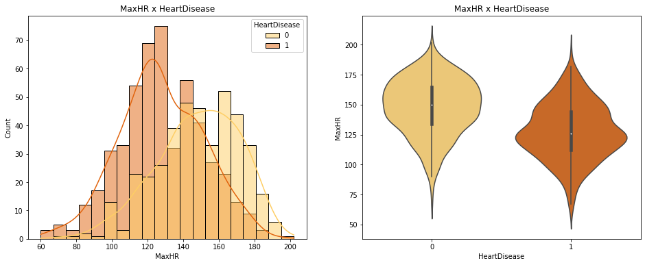

```python
fig, ax = plt.subplots(1, 2, figsize=(16, 6))
sns.histplot(data = df, hue = 'HeartDisease', x = 'MaxHR', kde = True, palette = pal, ax=ax[0]).set_title('MaxHR x HeartDisease')
sns.violinplot(data = df, x = 'HeartDisease', y = 'MaxHR', palette = pal, ax=ax[1]).set_title('MaxHR x HeartDisease')
fig.show()
```

**Pozorování**

- Pacienti se srdeční nemocí mají menší maximální srdeční tep.

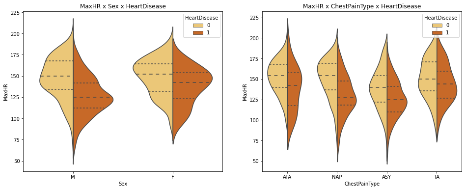

```python
fig, ax = plt.subplots(1, 2, figsize=(16, 6))
sns.violinplot(data = df, x = 'Sex', y = 'MaxHR', hue = 'HeartDisease', palette = pal, size = 6, aspect = 1.5, split = True, inner = 'quart', ax=ax[0]).set_title('MaxHR x Sex x HeartDisease')
sns.violinplot(data = df, x = 'ChestPainType', y = 'MaxHR', hue = 'HeartDisease', palette = pal, size = 6, aspect = 1.5, split = True, inner = 'quart', ax=ax[1]).set_title('MaxHR x ChestPainType x HeartDisease')
fig.show()
```

**Pozorování**

- Muži se srdečním onemocněním mají o něco menší průměrný tep než ženy.
- U pacientů s typem bolesti TA je maximální tepová frekvence nejvyrovnanější.

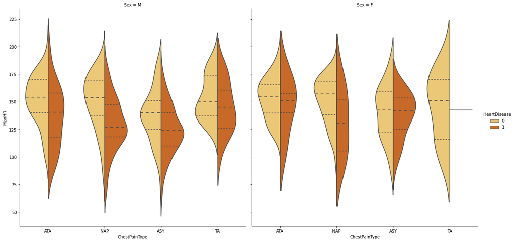

```python
sns.catplot(data = df, x = 'ChestPainType', y = 'MaxHR', hue = 'HeartDisease', col = 'Sex', kind="violin", split=True, inner = 'quart', palette = pal, size = 8)
fig.show()
```

**Pozorování**

- U žen je pouze u typu bolesti NAP znatelný výraznější pokles tepové frekvence u pacientů se srdeční poruchou.